# 2. Estimation and regression

## Likelihood Function Visualization

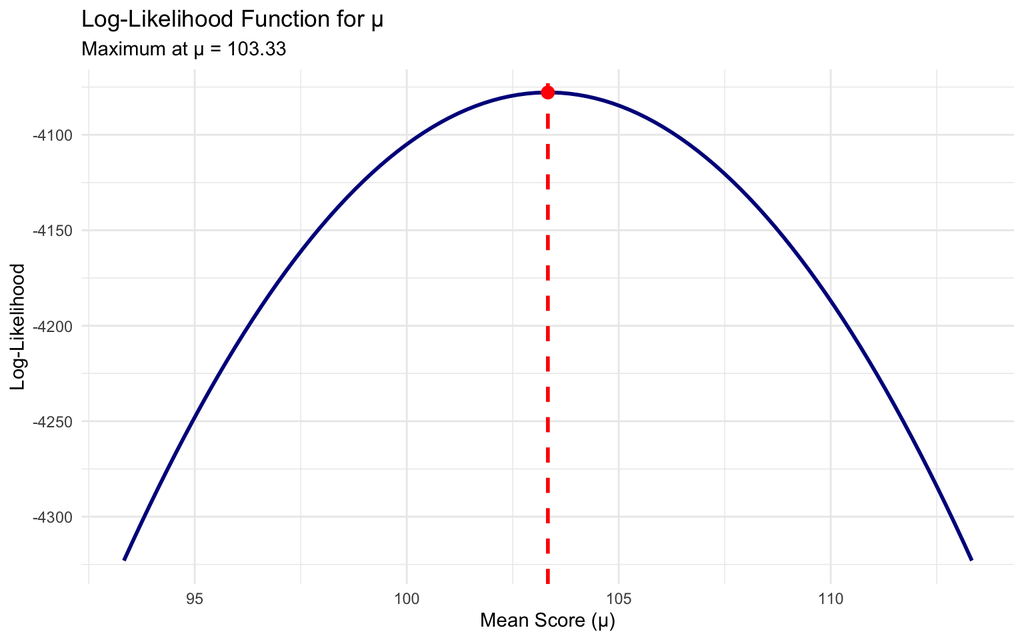

Log-likelihood surface for different values of μ

## Confidence Interval for μ

```r
# 95% confidence interval for μ
alpha <- 0.05
z_critical <- qnorm(1 - alpha/2)
se_mu <- sigma_mle / sqrt(n)
ci_lower <- mu_mle - z_critical * se_mu
ci_upper <- mu_mle + z_critical * se_mu

cat("95% Confidence Interval for μ:\n")
```

```
95% Confidence Interval for μ:
```

```r
cat("Lower bound:", round(ci_lower, 2))
```

```
Lower bound: 102.44
```

```r
cat("Upper bound:", round(ci_upper, 2))
```

```
Upper bound: 104.21
```

```r
cat("Margin of error:", round(z_critical * se_mu, 2))
```

```
Margin of error: 0.89
```

## MLE: Poisson Example

For an i.i.d. sample $X_1, \dots, X_n$ from a Poisson(λ) distribution, the log-likelihood is:
$$l(\lambda) = \sum_{i=1}^n \ln\left(\frac{\lambda^{X_i} e^{-\lambda}}{X_i!}\right) = (\ln \lambda) \sum X_i - n\lambda - \sum \ln(X_i!)$$

To find the maximum, we take the derivative with respect to λ and set it to zero:
$$\frac{dl}{d\lambda} = \frac{1}{\lambda}\sum X_i - n = 0$$
$$\implies \hat{\lambda}_{MLE} = \frac{\sum X_i}{n} = \bar{X}$$

For the Poisson distribution, the Method of Moments and the Maximum Likelihood estimates are the same.

## Gamma distribution

A law for a positive number: a waiting time, a rainfall amount, a claim size.

- Shape $\alpha>0$ is how many Poisson events you are waiting for.
- Scale $\lambda>0$ stretches the clock. Mean $\alpha\lambda$, variance $\alpha\lambda^2$.
- $\alpha=1$ is the exponential distribution: time until the first event.
- An integer $\alpha=k$ is the time until the $k$-th event in a Poisson process.
  $$f(x)=\frac{1}{\Gamma(\alpha)\lambda^\alpha}x^{\alpha-1}e^{-x/\lambda},\qquad x>0.$$

## Three gamma shapes

Same scale, three shapes. Shape 1 piles up at zero. Larger shape moves the mass to the right and makes a hump.

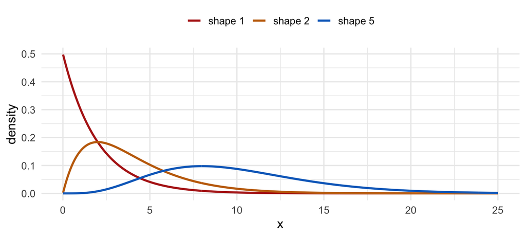

## Where a gamma is the model

- Time until the $k$-th arrival: customers, decays, packets. $k=1$ is the red curve.
- A size with no natural ceiling and a long right tail: insurance claims, daily rainfall.
- Service time in a queue, or time until recovery, when the histogram looks like the blue curve rather than a bell.
- The next fit is inter-arrival times of gamma rays. Those are waiting times.
- The fit writes the same law with a rate, $1/\lambda$. R’s `dgamma(..., rate = )` is that form. The curve does not change.

## MLE: Gamma Distribution Example

For the Gamma distribution, the log-likelihood is:
$$l(\alpha, \lambda) = n\alpha\ln(\lambda) - n\ln(\Gamma(\alpha)) + (\alpha-1)\sum\ln(X_i) - \lambda\sum X_i$$
The MLEs for α and λ don’t have a simple closed-form solution and must be found numerically by maximizing this function.

Let’s fit a Gamma distribution to the inter-arrival times of gamma-rays.

## MLE: Gamma Distribution Example

```
[1] "MLE for alpha: 1.0263"
```

```
[1] "MLE for lambda: 0.0128"
```

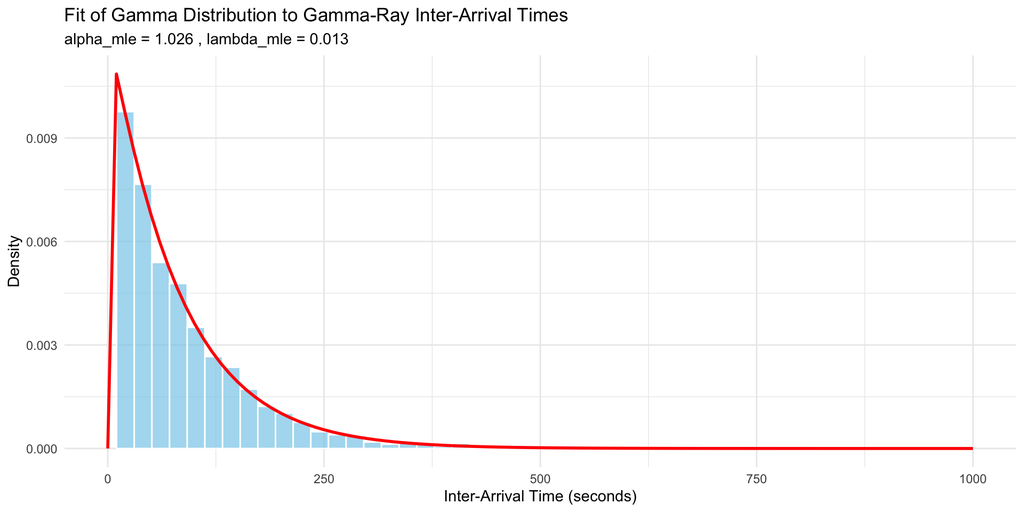

## Negative binomial

A law for a count, like the Poisson, with one extra fact: the variance is larger than the mean.

- Keep tossing a coin until you have $r$ successes. $X$ is the number of failures along the way.
- Mean $\mu=r(1-p)/p$. Variance $\mu+\mu^2/r$, which is always bigger than $\mu$.
- A Poisson count has variance equal to its mean. The negative binomial is what you get when that rate is itself random, drawn from the gamma on the last slides.
- Large $r$ pulls the extra term $\mu^2/r$ toward zero, and the law collapses back to the Poisson.

## Same mean, more spread

Mean fixed at 4. The Poisson is the narrowest. Small $r$ puts more mass at zero and a longer right tail.

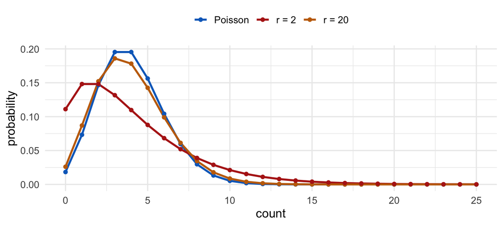

## Where a negative binomial is the model

- Insects on a plant, visits to a clinic, claims on a policy: many zeros, and a few units with a huge count.
- The Poisson fit is too tight there. The sample variance is larger than the sample mean, and the gamma mixture is the reason.
- The next fit is potato beetles per plant. $r$ and the mean are found numerically. There is no closed form, same as the gamma.

## MLE: Negative Binomial Example

Potato beetles per plant. The count is the negative binomial from the last slides.

```
[1] "MLE for r (size): 2.24"
```

```
[1] "MLE for mean (mu): 4.7"
```

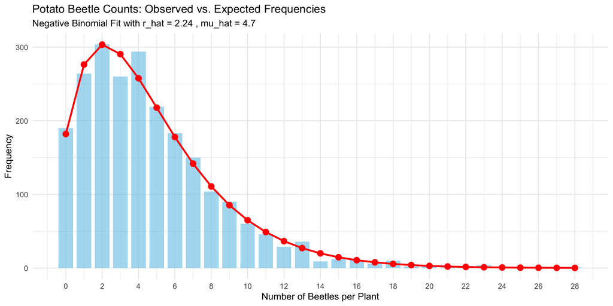

## Prediction Problems:

| Output Type | Problem Type | Example |
| --- | --- | --- |
| Binary | Classification | Spam detection |
| Categorical | Classification | Content categorization |
| Quantitative | Regression | House prices |
| Ordinal | Ranking | Customer satisfaction |

## The mean can depend on an input

- For a Gaussian model with fixed variance,

$$-\ell(\mu)=\frac1{2\sigma^2}\sum_i(y_i-\mu_i)^2+C.$$

- The best-fitting mean minimizes squared deviations.

$$\mu_i=ax_i+b.$$

## Averages within groups, then across groups

A quarter of the houses are small, and their average price is 2. The other three quarters are large, and their average price is 6. Prices are in the same thousands of dollars as the next slide.

- Ignore size, and the one number you can report is
  $$0.25\times 2+0.75\times 6=5.$$
- Keep size, and you report 2 for a small house and 6 for a large one.
- The line on the next slide is that second average, with living area in place of the two groups.

## How Does Zestimate Work?

[figure not shown]

Original Saratoga housing data, fitted line, and 2200 square foot prediction

Saratoga house prices

- 1,728 sales in the supplied file.
- $\hat y=13.44+113.12x$.
- $x$: thousands of square feet of living area.
- $y$: thousands of dollars.

What does the slope say at 2,200 square feet?

```
[ 13.439394   113.12254185] 262.30898606787036
```

## Housing Data Visualization

For Saratoga use the revised 1,728-row fit. Its intercept is extrapolation, not an identified land value.

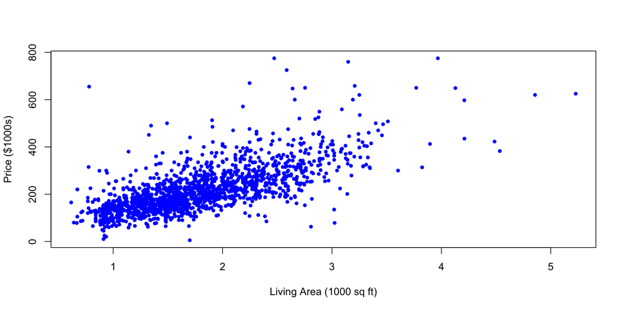

House prices vs living area in Saratoga County

## Fitting the Linear Model

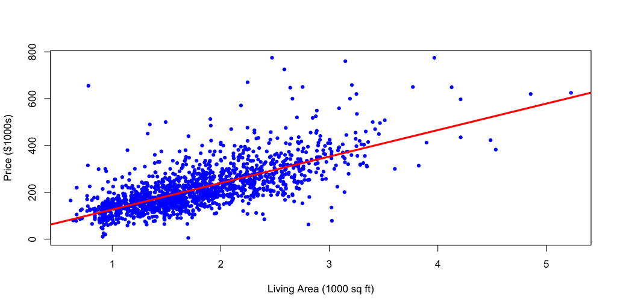

Linear regression line fitted to housing data

**R Code Explanation:**

- `lm()`: Fits linear model using least squares
- `price ~ livingArea`: Formula notation (dependent ~ independent)
- `abline()`: Adds regression line to plot

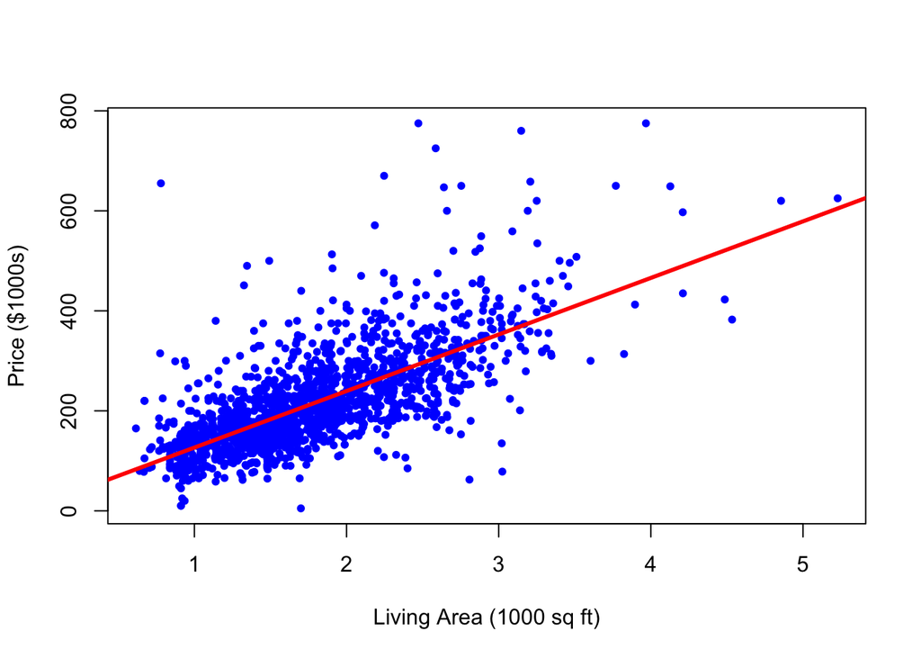

Original saved output: Fitting the Linear Model

## Model Coefficients

For Saratoga use the revised 1,728-row fit. Its intercept is extrapolation, not an identified land value.

```
(Intercept)  livingArea
   13.43939   113.12254
```

**Interpretation:**

- **Intercept** ($\beta_0$): Fitted value at zero living area, an extrapolation
- **Slope** ($\beta_1$): Price increase per 1000 sq ft
- **Economic significance**: Every additional 1000 sq ft increases price by $\beta_1 \times \$1000$

## Making Predictions

**Example:** Predict price for 2,200 sq ft house

$$\hat{y} = \beta_0 + \beta_1 \times 2.2$$

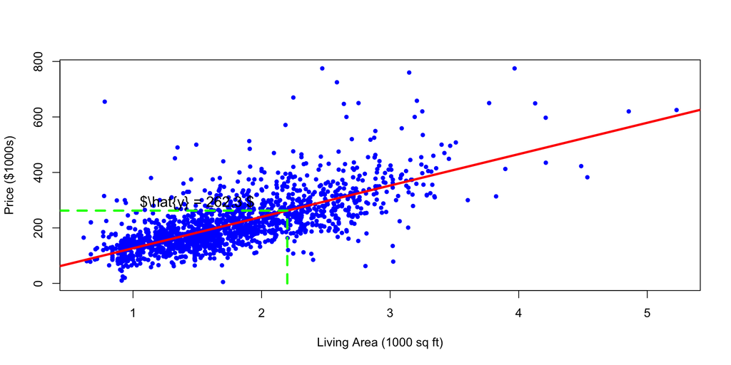

Prediction visualization for 2,200 sq ft house

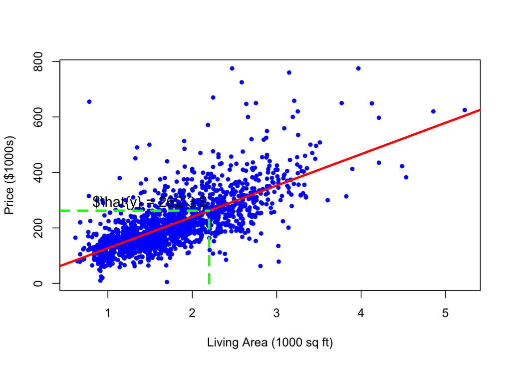

Original saved output: Making Predictions

## Apply to housing data

For Saratoga use the revised 1,728-row fit. Its intercept is extrapolation, not an identified land value.

|  | mle |  | mle_optim |
| --- | --- | --- | --- |
| (Intercept) | 13.44 | 13.44 | 13.40 |
| livingArea | 113.12 | 113.12 | 113.14 |

## One prediction for everyone?

[figure not shown]

The three observations used in the hand calculation

- Would you predict the same value at every $x$?
- Sketch a rule.
- Which point will a straight line miss?

A curve through every point is easy. Would you trust it at $x=4$?

## Residuals keep the units of the response

[figure not shown]

Residuals as vertical distances from the candidate line

$$e_i=y_i-\hat y_i$$

- Candidate line: $\hat y=1+x$.
- At $x=1$, observed $y=3$.
- Prediction: 2.
- Residual: **+1**.

**Would a negative residual sit above or below the line?**

## A loss for choosing the line

- We use the same convention throughout this calculation:

$$J(a,b)=\frac1{2n}\sum_i(a+bx_i-y_i)^2.$$

- Squaring prevents positive and negative errors from canceling.
- The factor $1/(2n)$ simplifies the gradient. It does not change the minimizing line.

## Why squared deviations appear

- The constant-mean case is the previous derivation: $\hat\mu=\bar y$.
- With a line, assume independent responses

$$Y_i\mid x_i\sim N(a+bx_i,\sigma^2).$$

- For fixed $\sigma^2$,

$$-\ell(a,b)=\frac1{2\sigma^2}\sum_i(y_i-a-bx_i)^2+C.$$

- Maximizing this likelihood gives the least-squares line. The same sum of squares, now in $a$ and $b$.

## Least squares slope and intercept

$$\hat b=\frac{\sum_i(x_i-\bar x)(y_i-\bar y)}{\sum_i(x_i-\bar x)^2},\qquad \hat a=\bar y-\hat b\,\bar x.$$

- The numerator pairs each point’s deviation in $x$ with its deviation in $y$.
- The denominator is the sum of the squared deviations in $x$. A point far from $\bar x$ gets a large vote.
- The intercept puts the line through the point of averages, $(\bar x,\bar y)$.
- $\hat a$ is the predicted $y$ at $x=0$. If the data are nowhere near zero, that prediction is an extrapolation.

## Variance of a new prediction

A new outcome at a chosen $x$ is the fitted line plus a fresh error. The line is estimated from the sample, so both pieces vary. Here $s$ is the residual standard deviation.

$$\operatorname{Var}=s^2\left(1+\frac1n+\frac{(x-\bar x)^2}{\sum_i(x_i-\bar x)^2}\right).$$

- The $1$ is the new error. It does not shrink as $n$ grows.
- $1/n$ is uncertainty in the height of the line.
- The last term grows as $x$ moves away from $\bar x$. The same denominator as in the slope.
- A band for the mean line drops the $1$. A band for one new outcome keeps it.

## Predictions as a matrix product

$$X=\begin{pmatrix}1&0\\1&1\\1&2\end{pmatrix},
\qquad\theta=\begin{pmatrix}1\\1\end{pmatrix},
\qquad X\theta=\begin{pmatrix}1\\2\\3\end{pmatrix}$$

```
[1. 2. 3.]
```

- One row produces one prediction.
- The column of ones supplies the intercept.

## Which array operation do you mean?

- With `X.shape == (3, 2)` and `theta.shape == (2,)`:

| NumPy expression | Meaning | Shape |
| --- | --- | --- |
| `X @ theta` | Three dot products | `(3,)` |
| `X * theta` | Elementwise scaling of columns | `(3, 2)` |
| `X.T` | Transpose | `(2, 3)` |
| `theta[:, None]` | Explicit column | `(2, 1)` |

- Predict the output shape before running each line. A one-dimensional array’s `.T` does not make it a column.

## When coefficients cannot be distinguished

- If two columns of $X$ are identical, only the sum of their coefficients affects $X\theta$.
- Adding 1 to one coefficient and subtracting 1 from the other leaves every prediction unchanged.
- Linear dependence can make the coefficients non-unique. We can still ask about predictions and the loss.

## A derivative is local sensitivity

- For a small change $\delta$,

$$J(\theta+\delta)\approx J(\theta)+\nabla J(\theta)^\top\delta.$$

- A partial derivative changes one parameter while holding the others fixed.
- Compare an analytic derivative with central finite differences:

$$\frac{J(\theta+\epsilon e_j)-J(\theta-\epsilon e_j)}{2\epsilon}.$$

## A fitted line on a larger sample

[figure not shown]

A line fitted to simulated curved data and its residuals

Which feature of the residual plot would you investigate?

## The experiment’s known mechanism

$$X\sim U(-2,2)$$

$$Y=1+2X+0.7X^2+\epsilon,\qquad \epsilon\sim N(0,1)$$

- We know the mechanism because we generated these observations.
- The straight line cannot represent the whole conditional mean.

## Curvature and influence

[figure not shown]

The fitted line before and after changing one response

- The rightmost response increases by 15.
- Its large squared error pulls the line.
- Curvature and an influential observation are different clues.

**Which feature of your residual plot supports your explanation?**

## More examples: the same regression questions

- The original **Tiger Woods** example asks why one response can dominate a fit.
- **Mammal brain and body mass** asks whether a different scale reveals structure.
- Compare what changes when the response scale or observation changes.

## Tiger Woods: what does the residual mean?

[figure not shown]

PGA earnings residuals on dollar and log-dollar scales

- Same 195 golfers and predictors, different response scale.
- Tiger Woods earns much more than the dollar-scale fit predicts.
- A log transform changes which errors matter. It does not prove a causal explanation.

[output not shown]

## Golf Performance Prediction

Use the verified 2000 PGA data. Raw coefficient sizes across different units do not rank causal importance. These fits are in-sample diagnostics.

**Dave Pelz: From Rocket Scientist to Golf Analytics Pioneer**

- NASA Apollo program engineer turned golf instructor
- Applied data analytics to revolutionize golf instruction
- Discovered optimal putt speed: 17 inches past hole if missed
- Author of *Short Game Bible* and *Putting Bible*

**Data-Driven Golf Insight:** Short game matters most for overall scoring

## PGA Tour Performance Analysis

Use the verified 2000 PGA data. Raw coefficient sizes across different units do not rank causal importance. These fits are in-sample diagnostics.

**Dataset:** 195 professional golfers, 2000 PGA Tour season

**Variables:**

- `money`: Official dollar winnings
- `nevents`: Number of official PGA events
- `drivedist`: Average driving distance (yards)
- `gir`: Greens in regulation (percentage)
- `avgputts`: Average putts per round

**Goal:** Determine which factors most influence tour earnings

## Loading and Examining Golf Data

Use the verified 2000 PGA data. Raw coefficient sizes across different units do not rank causal importance. These fits are in-sample diagnostics.

```r
d00 = read.csv("../data/pga-2000.csv")
d18 = read.csv("../data/pga-2018.csv")
```

```r
library(broom)
library(dplyr, warn.conflicts = FALSE)
model00 = lm(money ~ nevents + drivedist + gir + avgputts, data=d00)
model00 %>% broom::tidy() %>% knitr::kable(digits=2)
```

| term | estimate | std.error | statistic | p.value |
| --- | --- | --- | --- | --- |
| (Intercept) | 14856637.77 | 4206466.17 | 3.53 | 0.00 |
| nevents | -30066.53 | 11183.31 | -2.69 | 0.01 |
| drivedist | 21309.72 | 6912.98 | 3.08 | 0.00 |
| gir | 120855.16 | 17429.37 | 6.93 | 0.00 |
| avgputts | -15203044.72 | 2000904.79 | -7.60 | 0.00 |

## Residual Analysis: The Tiger Woods Effect

Use the verified 2000 PGA data. Raw coefficient sizes across different units do not rank causal importance. These fits are in-sample diagnostics.

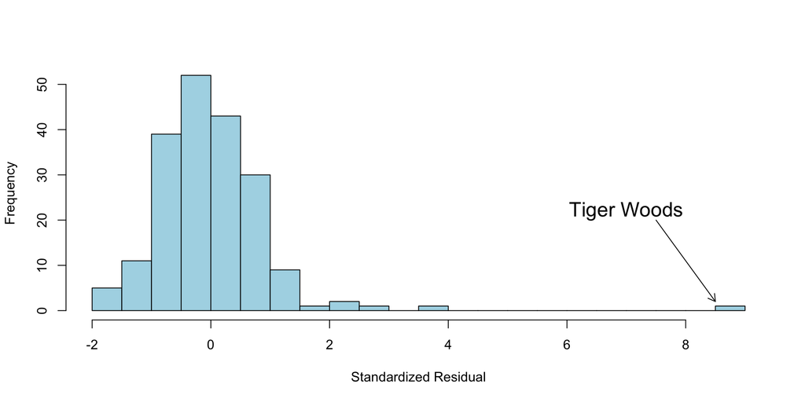

Residual distribution showing extreme outlier

**Problem:** Extreme outlier suggests need for transformation

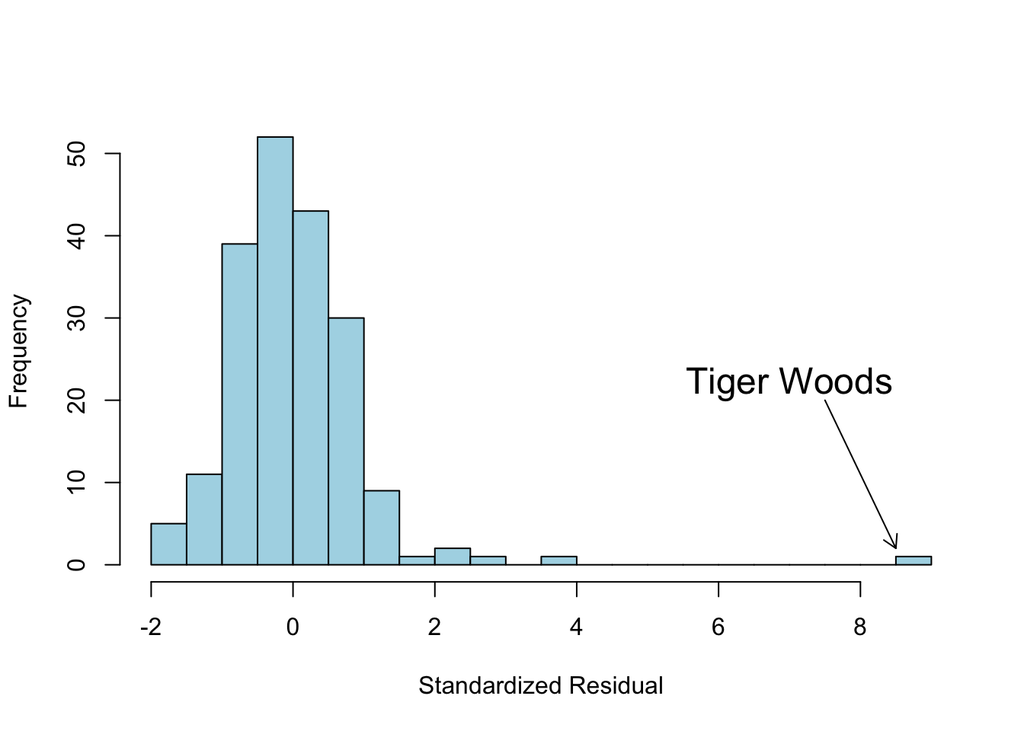

Original saved output: Residual Analysis: The Tiger Woods Effect

## Log Transformation Improves Model

Use the verified 2000 PGA data. Raw coefficient sizes across different units do not rank causal importance. These fits are in-sample diagnostics.

```r
model00log = lm(log(money) ~ nevents + drivedist + gir + avgputts, data=d00)
model00log %>% broom::tidy() %>% knitr::kable(digits=2)
```

| term | estimate | std.error | statistic | p.value |
| --- | --- | --- | --- | --- |
| (Intercept) | 36.15 | 3.58 | 10.10 | 0.00 |
| nevents | -0.01 | 0.01 | -0.94 | 0.35 |
| drivedist | 0.01 | 0.01 | 2.40 | 0.02 |
| gir | 0.17 | 0.01 | 11.18 | 0.00 |
| avgputts | -21.13 | 1.70 | -12.42 | 0.00 |

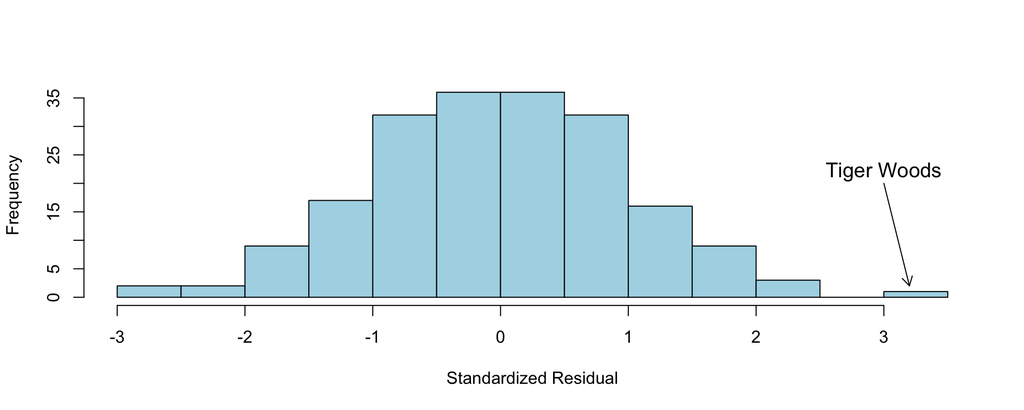

Improved residual distribution after log transformation

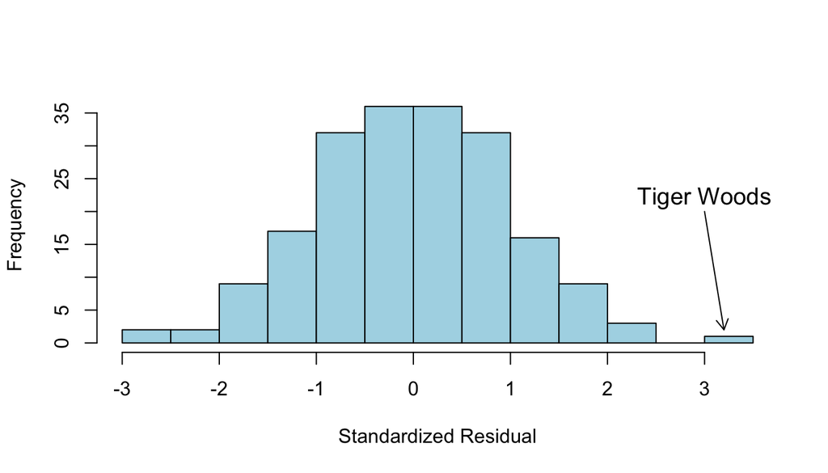

Original saved output: Log Transformation Improves Model

## Variable Selection and Final Model

Use the verified 2000 PGA data. Raw coefficient sizes across different units do not rank causal importance. These fits are in-sample diagnostics.

**Remove `nevents`** (t-statistic < 1.5, not significant)

```r
m1 = lm(log(money) ~ drivedist + gir + avgputts, data=d00)
m1 %>% broom::tidy() %>% knitr::kable(digits=2)
```

| term | estimate | std.error | statistic | p.value |
| --- | --- | --- | --- | --- |
| (Intercept) | 36.17 | 3.58 | 10.11 | 0.00 |
| drivedist | 0.01 | 0.01 | 2.50 | 0.01 |
| gir | 0.17 | 0.01 | 11.19 | 0.00 |
| avgputts | -21.37 | 1.68 | -12.70 | 0.00 |

**Key Insights:**

- **Putting**: Most important factor (highest coefficient magnitude)
- **GIR**: $\hat{\beta} = 0.17$ → 1% GIR increase = 18% earnings boost
- **Driving**: $\hat{\beta} = 0.014$ → 10-yard increase = 15% earnings boost

## Performance Outliers Analysis

Use the verified 2000 PGA data. Raw coefficient sizes across different units do not rank causal importance. These fits are in-sample diagnostics.

**Over-performers** (earning more than predicted):

- Tiger Woods, Phil Mickelson, Ernie Els
- Won major championships with high prize money
- **Tiger Woods**: 9 standard deviations above prediction!

**Under-performers** (earning less than predicted):

- Strong technical statistics but lower earnings
- Possible factors: tournament pressure, event selection, mental game

**Practical Application:** Model identifies players exceeding/falling short of statistical expectations

## Golf Analytics Takeaways

Use the verified 2000 PGA data. Raw coefficient sizes across different units do not rank causal importance. These fits are in-sample diagnostics.

1. **Short game dominance**: Putting has greatest impact on earnings
2. **Power advantage**: Driving distance provides significant competitive edge
3. **Accuracy matters**: Greens in regulation crucial for success
4. **Outlier insights**: Model reveals over/under-performers
5. **Data transformation**: Log scale better captures exponential earnings distribution

**Modern relevance:** Analytics-driven approach now standard in professional golf training and strategy

## Mammals: a change of scale

[figure not shown]

The original 62 mammal species on original and log scales

- The fitted relation is $\log(\mathrm{Brain})\approx2.183+0.743\log(\mathrm{Body})$.
- Doubling body mass multiplies fitted brain mass by $2^{0.743}\approx1.67$.
- A large residual is a modeling question, not a measure of intelligence.

```
2.1832796605662286 0.7431983221963678 1.673882572282309
```

## Case Study: Mammal Brain vs Body Weight

Brain/body residuals do not rank intelligence. Exponentiating a log fit does not automatically estimate the arithmetic conditional mean.

**Dataset:** 62 mammal species (Jerison, 1973) - Brain weight (grams) - Body weight (kilograms)

```r
mammals = read.csv("../data/mammals.csv")
head(mammals) %>% knitr::kable()
```

| Mammal | Brain | Body |
| --- | --- | --- |
| African_elephant | 5712.0 | 6654.000 |
| African_giant_pouched_rat | 6.6 | 1.000 |
| Arctic_Fox | 44.5 | 3.385 |
| Arctic_ground_squirrel | 5.7 | 0.920 |
| Asian_elephant | 4603.0 | 2547.000 |
| Baboon | 179.5 | 10.550 |

**Question:** How does brain size relate to body size across species?

## Linear Model: Poor Fit

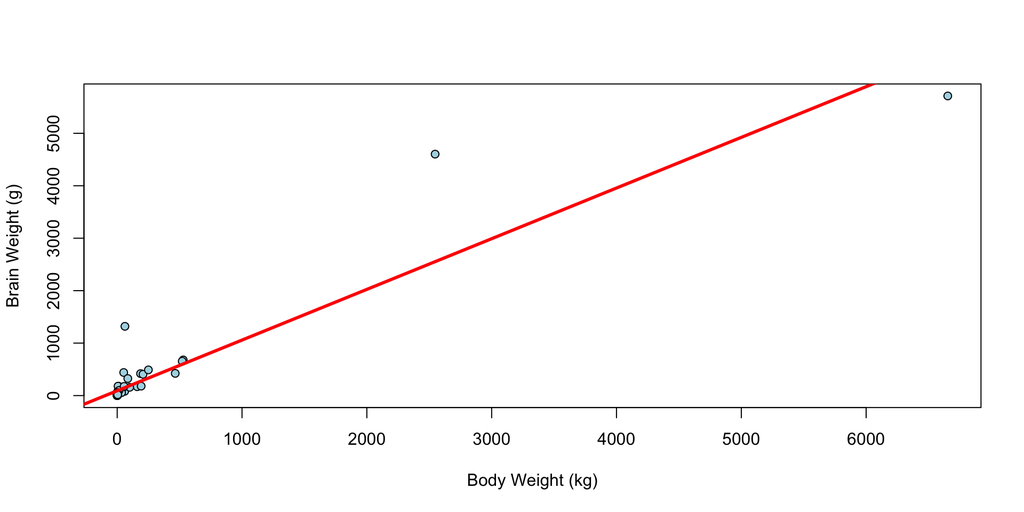

Linear model shows poor fit with outliers

**Problems:** Outliers, non-constant variance, poor fit

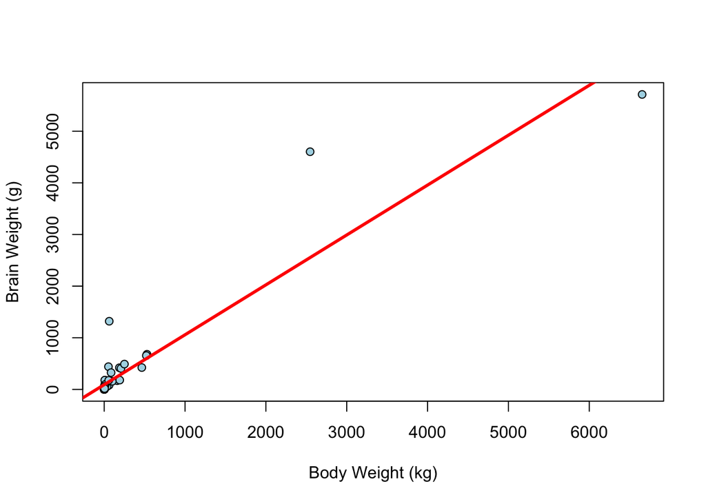

Original saved output: Linear Model: Poor Fit

## Residual Analysis Shows Problems

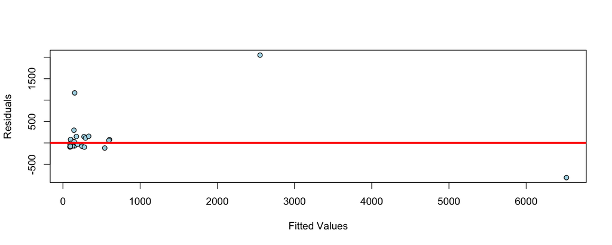

Residuals show heteroscedasticity

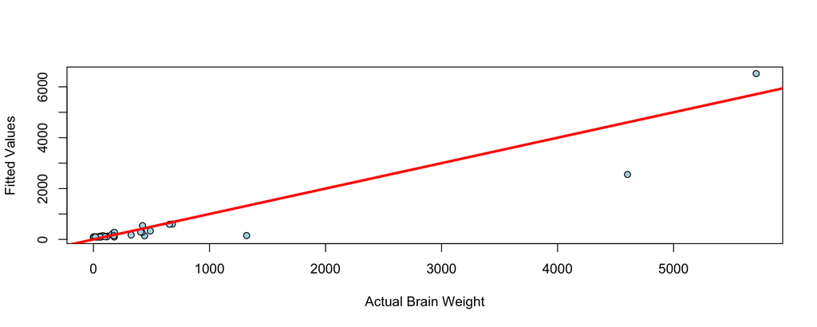

Fitted vs actual shows nonlinearity

**Diagnosis:** Need transformation to fix model assumptions

## Log-Log Transformation: Much Better!

```r
model_log = lm(log(Brain) ~ log(Body), data=mammals)
model_log %>% broom::tidy() %>% knitr::kable(digits=3)
```

| term | estimate | std.error | statistic | p.value |
| --- | --- | --- | --- | --- |
| (Intercept) | 2.183 | 0.107 | 20.439 | 0 |
| log(Body) | 0.743 | 0.032 | 23.477 | 0 |

**Model:** $\log(\text{Brain}) = 2.18 + 0.74 \times \log(\text{Body})$

**Interpretation:** - 10% increase in body weight → 7.4% increase in brain weight - Brain weight scales as Body<sup>0.74</sup> (allometric scaling)

## Improved Residual Diagnostics

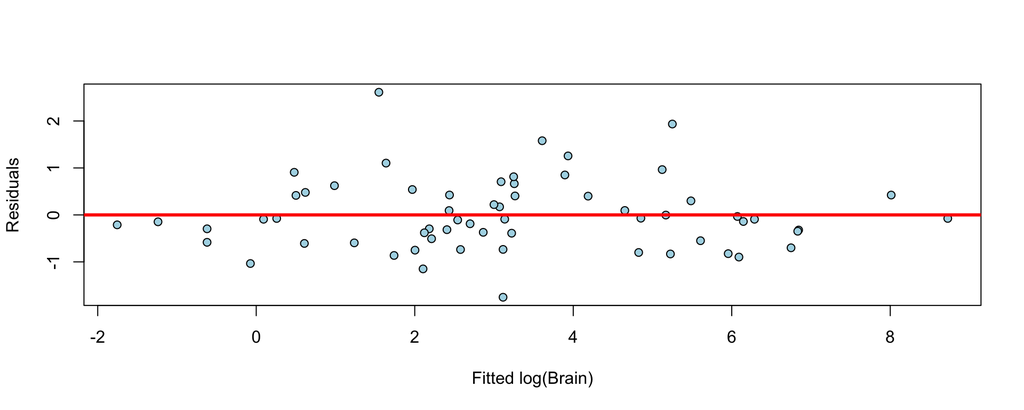

Residuals now show constant variance

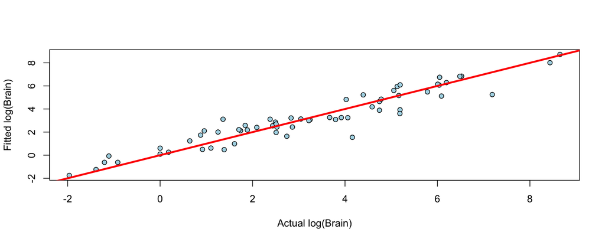

Strong linear relationship achieved

**Diagnostic question:** Does the transformed residual plot support a linear mean and roughly constant spread?

## Outlier analysis: mammal brain/body residuals

Brain/body residuals do not rank intelligence. Exponentiating a log fit does not automatically estimate the arithmetic conditional mean.

```r
res = model_log$residuals/sd(model_log$residuals)
outliers = base::order(res, decreasing = TRUE)[1:5]
cbind(mammals[outliers,],
      Std.Res = res[outliers], Residual=model_log$residuals[outliers],
      Fit = exp(model_log$fitted.values[outliers])) %>% knitr::kable(digits=2)
```

|  | Mammal | Brain | Body | Std.Res | Residual | Fit |
| --- | --- | --- | --- | --- | --- | --- |
| 11 | Chinchilla | 64.0 | 0.42 | 3.41 | 2.61 | 4.70 |
| 34 | Man | 1320.0 | 62.00 | 2.53 | 1.93 | 190.67 |
| 50 | Rhesus_monkey | 179.0 | 6.80 | 2.06 | 1.58 | 36.89 |
| 6 | Baboon | 179.5 | 10.55 | 1.64 | 1.26 | 51.13 |
| 42 | Owl_monkey | 15.5 | 0.48 | 1.44 | 1.10 | 5.14 |

**Key Finding:** Humans and some small mammals have disproportionately large brains!

## Dummy Variables

A 1/0 column standing in for a yes/no feature. The intercept is the mean when that column is 0. The coefficient is how the mean shifts when it is 1. “Has a garage” is this: one column.

A factor with more than two levels is the same idea, repeated.

## Dummy Variables: $k$ levels, $k-1$ columns

Neighborhood is A, B, or C. You cannot put $\{A, B, C\}$ into a sum. You make two columns and omit A as the reference:

| House | $I_B$ | $I_C$ |
| --- | --- | --- |
| A | 0 | 0 |
| B | 1 | 0 |
| C | 0 | 1 |

The intercept is the mean for A. The coefficient on $I_B$ is how B differs from A. Four neighborhoods would be three columns.

## Dummy Variables: the reference is a choice

R’s `lm` drops the first level of a factor. `factor(nbhd, levels = c("A","B","C"))` makes A the reference. That is a modeling decision, not a default to ignore.

If you want “typical house” as the baseline, put that level first. If you change the reference, every coefficient changes and the fitted values do not.

## Simple Predictive Rules

**Mean Rule:**
$$f(x) = \bar{y} = \frac{1}{n} \sum_{i=1}^n y_i$$

**Binary Classification (Thresholding):**
$$f(x) = \begin{cases}
1 & \text{if } \bar{y} > 0.5 \\
0 & \text{if } \bar{y} \leq 0.5
\end{cases}$$

**Nearest Neighbor Rule:**
$$f(x) = y_{i^*}, \quad \text{where } i^* = \arg\min_{i=1,\ldots,n} \|x_i - x\|$$

**Trade-off:** Mean rule (high bias, low variance) vs NN rule (low bias, high variance)

## Logarithmic and Power Transformations

**Problem:** Not all relationships are linear!

- Linear models assume: $y = \beta_0 + \beta_1 x$
- Reality: Many relationships are multiplicative or exponential
- **Solution:** Transform variables to linearize relationships
- **Key insight:** Linear regression on transformed data

**Examples:** Stock prices, population growth, brain-body relationships

## When Linear Models Fail: Apple Stock Growth

**Apple Stock (2000-2024):** Exponential growth pattern

```
[1] "AAPL"
```

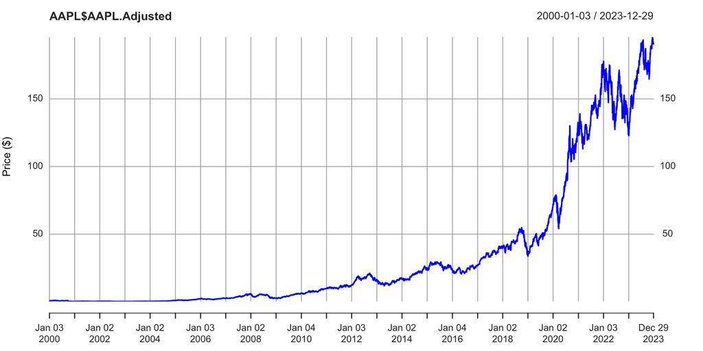

Apple stock shows exponential growth over time

**Observation:** Linear model would be poor fit for exponential growth

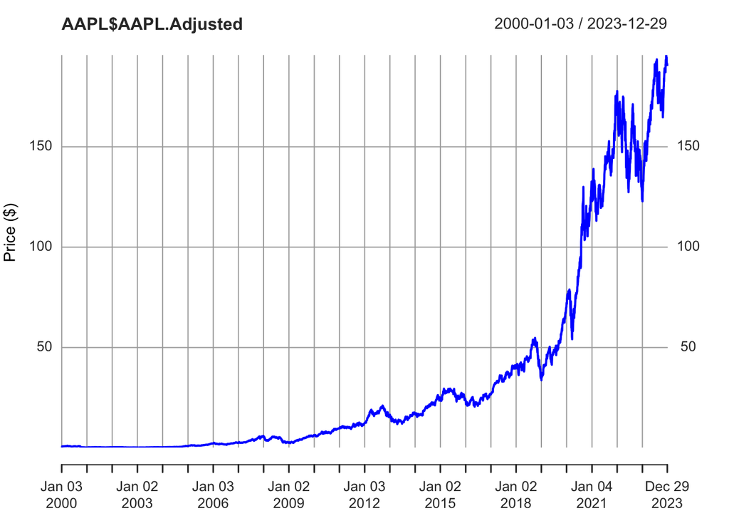

Original saved output: When Linear Models Fail: Apple Stock Growth

## Linear Model vs Exponential Growth

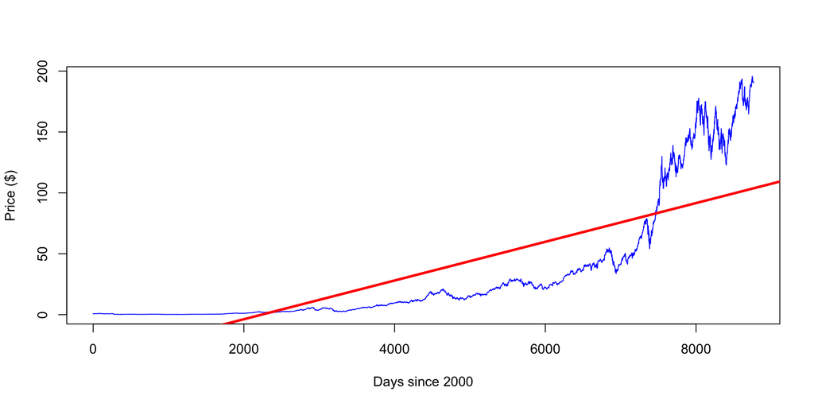

Linear model fails to capture exponential growth

**Problem:** Straight line cannot capture curved relationship

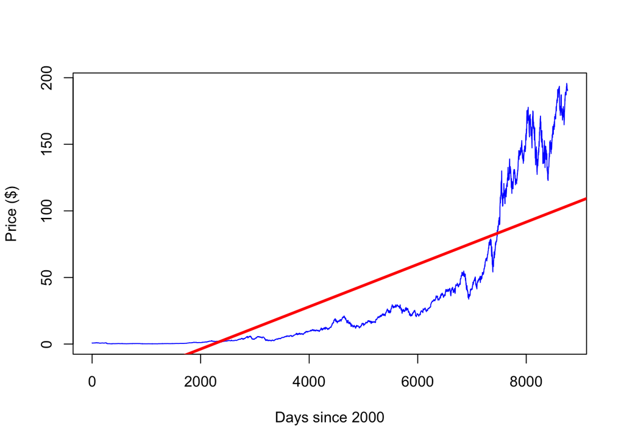

Original saved output: Linear Model vs Exponential Growth

## The Mathematics of Compounding

**Compounding Formula:**
$$y = y_0 \times (1 + r/n)^{nt}$$

**Example:** $1,000 investment at 10% annual rate - Annual compounding: $y = 1000 \times (1.1)^1 = \$1,100$ - Monthly compounding: $y = 1000 \times (1 + 0.1/12)^{12} = \$1,105$

## Euler’s Number and Continuous Compounding

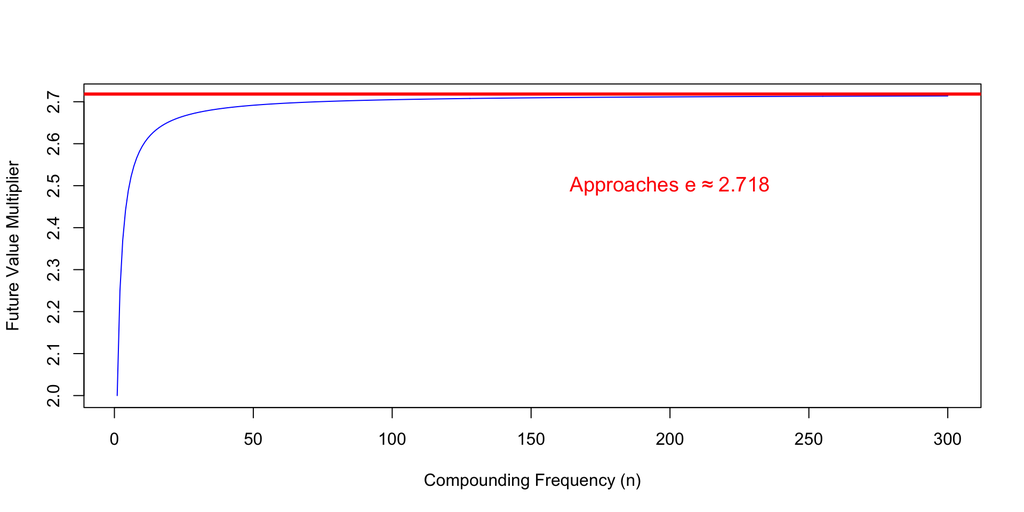

Compound growth approaches e^r as frequency increases

**Key Limit:** $(1+r/n)^n \rightarrow e^r$ as $n \rightarrow \infty$

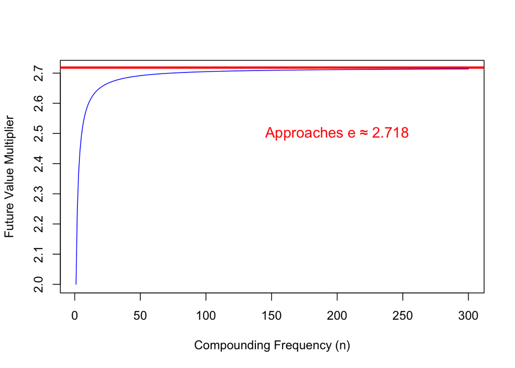

Original saved output: Euler’s Number and Continuous Compounding

## Exponential Models and Log Transformation

**Exponential Growth Model:**
$$y = y_0 \times e^{\beta^T x}$$

**Log Transformation:**
$$\log y = \log y_0 + \beta^T x$$

- **Multiplicative** relationships become **additive**
- **Exponential** curves become **linear**
- Can use standard linear regression on transformed data
- **Interpretation:** Coefficients represent percentage changes

## Power Law Relationships

**Power Law Model:**
$$y = \beta_0 x^{\beta_1}$$

**Examples:**

- City size vs. number of cars
- Metabolic rate vs. body mass
- Website traffic vs. page rank

**Log-Log Transformation:**
$$\log y = \log \beta_0 + \beta_1 \log x$$

**Interpretation:** $\beta_1$ is the elasticity (% change in $y$ per % change in $x$)

## Transformation Guidelines

1. **Exponential growth** → Log transform $y$: $\log(y) = \beta_0 + \beta_1 x$
2. **Power relationships** → Log-log transform: $\log(y) = \beta_0 + \beta_1 \log(x)$
3. **Check requirements:** Variables must be positive for log transformation
4. **Don’t transform:** Binary/dummy variables (0/1)
5. **Diagnostic check:** Residual plots after transformation

**Remember:** Coefficients in log models represent percentage effects!

## Practical Applications

**Business Examples:**

- Revenue growth over time (exponential)
- Price elasticity of demand (power law)
- Economies of scale (power relationships)

**Scientific Examples:**

- Population dynamics
- Allometric scaling (brain-body, metabolic rates)
- Network effects (Metcalfe’s law)

**Key Insight:** Transform to reveal hidden linear structure

## Predictive modeling practice

- Practice small calculations and explanations:
- Conditional means and the assumptions behind a prediction.
- CDFs, likelihood, and sampling variability.
- Fitted values, residuals, loss, and one gradient update.
- Compare a numerical prediction with a predicted class probability.

## Explain the fitted model

Work individually.

What does a slope of 2 mean in the units of $x$ and $y$?

What does a curved residual pattern suggest?

Why does a small training loss leave a question about future predictions unanswered?